# Exercises

Import libraries and attach

```r
library(ISLR)
library(car)
attach(Auto)
```

## Excercise 8

```r
fit1 = lm(mpg ~ horsepower)
summary(fit1)
```

```
Call:
lm(formula = mpg ~ horsepower)

Residuals:
     Min       1Q   Median       3Q      Max
-13.5710  -3.2592  -0.3435   2.7630  16.9240

Coefficients:
             Estimate Std. Error t value Pr(>|t|)
(Intercept) 39.935861   0.717499   55.66   <2e-16 ***
horsepower  -0.157845   0.006446  -24.49   <2e-16 ***
---
Signif. codes:  0 ‘***’ 0.001 ‘**’ 0.01 ‘*’ 0.05 ‘.’ 0.1 ‘ ’ 1

Residual standard error: 4.906 on 390 degrees of freedom
Multiple R-squared:  0.6059,    Adjusted R-squared:  0.6049
F-statistic: 599.7 on 1 and 390 DF,  p-value: < 2.2e-16
```

## 8.a.i

There is a relationship between horsepower and mpg because there is low p-value

### 8.a.ii

The relationship is very strong. p-value is very close to zero, denoted by ***.

### 8.a.iii

The relationship is negative because Estimate is negative (-0.15)

```r
#Prediction
predict(fit1, data.frame(horsepower=98), interval='prediction')
```

```
       fit     lwr      upr
1 24.46708 14.8094 34.12476
```

```r
#Confidence
predict(fit1, data.frame(horsepower=98), interval='confidence')
```

```
       fit      lwr      upr
1 24.46708 23.97308 24.96108
```

### 8.a.iv

For HP of 98, Predicted 24.5mpg. Confidence and Prediction intervals above

### 8.b

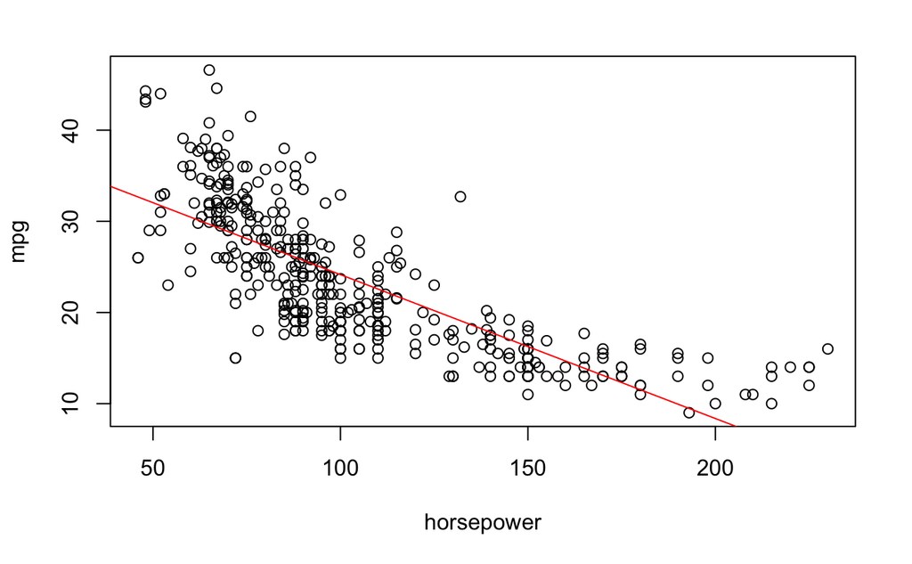

```r
plot(horsepower,mpg)
abline(fit1, col='red')
```

### 8.c

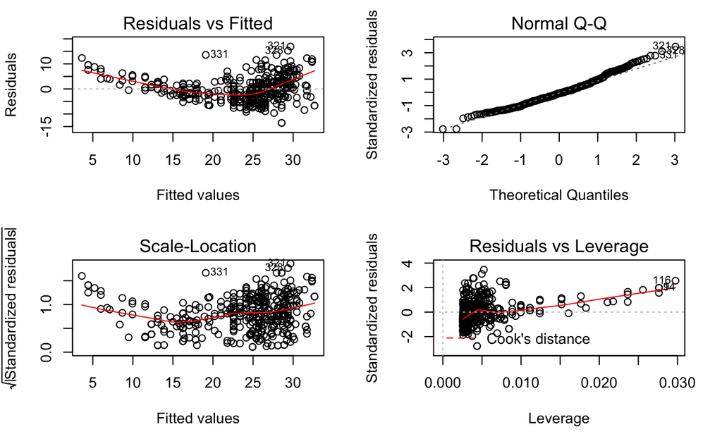

```r
par(mfrow=c(2,2))
plot(fit1)
```

### 8.c

There is a non-linear pattern in the fitted values that follows a parabola trajectory.

## Execise 9

### 9.a

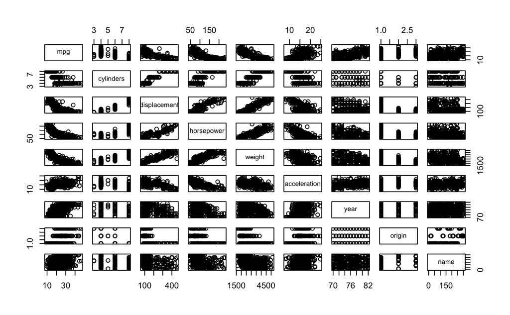

```r
plot(Auto)
```

### 9.b

```r
cor(subset(Auto, select=-name))
```

```
                    mpg  cylinders displacement horsepower     weight acceleration
mpg           1.0000000 -0.7776175   -0.8051269 -0.7784268 -0.8322442    0.4233285
cylinders    -0.7776175  1.0000000    0.9508233  0.8429834  0.8975273   -0.5046834
displacement -0.8051269  0.9508233    1.0000000  0.8972570  0.9329944   -0.5438005
horsepower   -0.7784268  0.8429834    0.8972570  1.0000000  0.8645377   -0.6891955
weight       -0.8322442  0.8975273    0.9329944  0.8645377  1.0000000   -0.4168392
acceleration  0.4233285 -0.5046834   -0.5438005 -0.6891955 -0.4168392    1.0000000
year          0.5805410 -0.3456474   -0.3698552 -0.4163615 -0.3091199    0.2903161
origin        0.5652088 -0.5689316   -0.6145351 -0.4551715 -0.5850054    0.2127458
                   year     origin
mpg           0.5805410  0.5652088
cylinders    -0.3456474 -0.5689316
displacement -0.3698552 -0.6145351
horsepower   -0.4163615 -0.4551715
weight       -0.3091199 -0.5850054
acceleration  0.2903161  0.2127458
year          1.0000000  0.1815277
origin        0.1815277  1.0000000
```

### 9.c

```r
fit2=lm(mpg~.-name, data=Auto)
summary(fit2)
```

```
Call:
lm(formula = mpg ~ . - name, data = Auto)

Residuals:
    Min      1Q  Median      3Q     Max
-9.5903 -2.1565 -0.1169  1.8690 13.0604

Coefficients:
               Estimate Std. Error t value Pr(>|t|)
(Intercept)  -17.218435   4.644294  -3.707  0.00024 ***
cylinders     -0.493376   0.323282  -1.526  0.12780
displacement   0.019896   0.007515   2.647  0.00844 **
horsepower    -0.016951   0.013787  -1.230  0.21963
weight        -0.006474   0.000652  -9.929  < 2e-16 ***
acceleration   0.080576   0.098845   0.815  0.41548
year           0.750773   0.050973  14.729  < 2e-16 ***
origin         1.426141   0.278136   5.127 4.67e-07 ***
---
Signif. codes:  0 ‘***’ 0.001 ‘**’ 0.01 ‘*’ 0.05 ‘.’ 0.1 ‘ ’ 1

Residual standard error: 3.328 on 384 degrees of freedom
Multiple R-squared:  0.8215,    Adjusted R-squared:  0.8182
F-statistic: 252.4 on 7 and 384 DF,  p-value: < 2.2e-16
```

### 9.c.i

Yes, overall p-value is statistically significant

### 9.c.ii

Displacement, weight, year, and origin are statistically significant

### 9.c.iii

The coefficient is 0.75 which suggest improved mpg per year

### 9.d

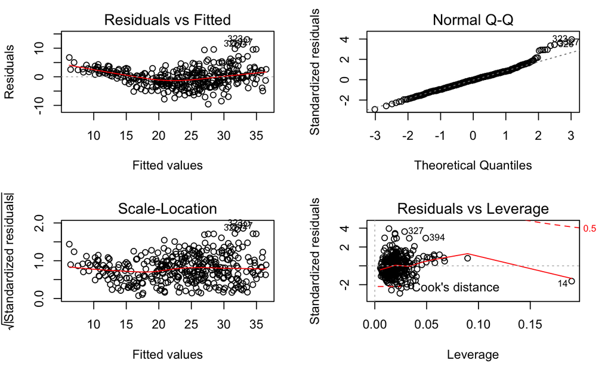

```r
par(mfrow=c(2,2))
plot(fit2)
```

There is a parabolic pattern in the Residual vs Fitted values graph suggesting non-linearity. The residual plot does have observations with unusually large leverage (14) and outliers (327, 394).

### 9.e

```r
fit3=lm(formula = mpg ~ . + displacement * acceleration * cylinders * weight * horsepower - name, data = Auto)
summary(fit3)
```

```
Call:
lm(formula = mpg ~ . + displacement * acceleration * cylinders *
    weight * horsepower - name, data = Auto)

Residuals:
    Min      1Q  Median      3Q     Max
-7.8560 -1.4192  0.0024  1.3975 12.5339

Coefficients:
                                                        Estimate Std. Error t value
(Intercept)                                            1.329e+02  4.172e+02   0.319
cylinders                                             -3.008e+01  7.466e+01  -0.403
displacement                                           1.843e+00  3.056e+00   0.603
horsepower                                            -4.051e+00  4.262e+00  -0.950
weight                                                -1.284e-01  1.375e-01  -0.934
acceleration                                          -2.481e+01  2.518e+01  -0.985
year                                                   7.467e-01  4.684e-02  15.943
origin                                                 7.128e-01  2.610e-01   2.731
displacement:acceleration                             -5.660e-02  1.785e-01  -0.317
cylinders:displacement                                -2.363e-01  4.243e-01  -0.557
cylinders:acceleration                                 5.363e+00  4.713e+00   1.138
displacement:weight                                   -3.014e-06  9.362e-04  -0.003
weight:acceleration                                    1.281e-02  8.232e-03   1.556
cylinders:weight                                       1.677e-02  2.295e-02   0.731
displacement:horsepower                               -1.329e-03  3.390e-02  -0.039
horsepower:acceleration                                4.217e-01  2.558e-01   1.648
cylinders:horsepower                                   8.610e-01  6.601e-01   1.304
horsepower:weight                                      1.778e-03  1.459e-03   1.219
cylinders:displacement:acceleration                    2.958e-03  2.547e-02   0.116
displacement:weight:acceleration                      -2.142e-05  5.449e-05  -0.393
cylinders:displacement:weight                          3.617e-06  1.279e-04   0.028
cylinders:weight:acceleration                         -2.074e-03  1.432e-03  -1.449
displacement:horsepower:acceleration                  -5.689e-04  1.995e-03  -0.285
cylinders:displacement:horsepower                     -6.377e-04  4.377e-03  -0.146
cylinders:horsepower:acceleration                     -9.099e-02  4.182e-02  -2.176
displacement:horsepower:weight                        -3.833e-06  1.034e-05  -0.371
horsepower:weight:acceleration                        -1.677e-04  8.720e-05  -1.924
cylinders:horsepower:weight                           -2.972e-04  2.113e-04  -1.407
cylinders:displacement:weight:acceleration             3.621e-06  7.627e-06   0.475
cylinders:displacement:horsepower:acceleration         1.650e-04  2.600e-04   0.634
```

[output cut: 30 more lines]

```
displacement:horsepower:weight                         0.71099
horsepower:weight:acceleration                         0.05520 .
cylinders:horsepower:weight                            0.16030
cylinders:displacement:weight:acceleration             0.63525
cylinders:displacement:horsepower:acceleration         0.52623
displacement:horsepower:weight:acceleration            0.42985
cylinders:displacement:horsepower:weight               0.62162
cylinders:horsepower:weight:acceleration               0.02404 *
cylinders:displacement:horsepower:weight:acceleration  0.29871
---
Signif. codes:  0 ‘***’ 0.001 ‘**’ 0.01 ‘*’ 0.05 ‘.’ 0.1 ‘ ’ 1

Residual standard error: 2.707 on 358 degrees of freedom
Multiple R-squared:  0.8899,    Adjusted R-squared:  0.8797
F-statistic: 87.67 on 33 and 358 DF,  p-value: < 2.2e-16
```

Acceleration and horsepower have the greatest interaction. Our R-squared values improved by using this model. Let’s examine the residuals vs fitted value graph.

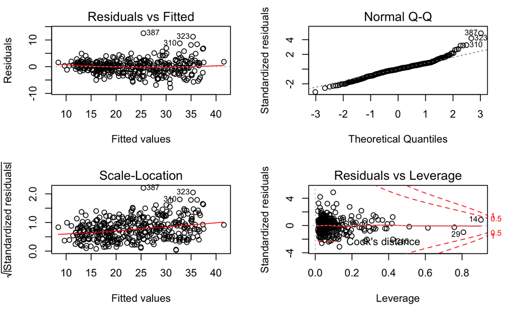

```r
par(mfrow=c(2,2))
plot(fit3)
```

There does not seem to be any noticable pattern in the residuals vs fitted graph suggesting the correlation fits the data. However, a funnel shape is present in the residual graph which is a sign of heteroscedasticity, meaning the magnitude of residuals tends to increase with the fitted values.

### 9.f

Because of heteroscedasticity, perhaps logging the response may improve the model.

```r
fit4=lm(log(mpg) ~ . + displacement * acceleration * weight * horsepower * cylinders - name, data = Auto)
par(mfrow=c(2,2))
summary(fit4)
```

```
Call:
lm(formula = log(mpg) ~ . + displacement * acceleration * weight *
    horsepower * cylinders - name, data = Auto)

Residuals:
     Min       1Q   Median       3Q      Max
-0.33091 -0.05914  0.00711  0.05837  0.46252

Coefficients:
                                                        Estimate Std. Error t value
(Intercept)                                            2.850e+00  1.590e+01   0.179
cylinders                                             -3.164e-01  2.846e+00  -0.111
displacement                                           6.279e-02  1.165e-01   0.539
horsepower                                            -1.126e-01  1.625e-01  -0.693
weight                                                -2.533e-03  5.241e-03  -0.483
acceleration                                          -7.188e-01  9.597e-01  -0.749
year                                                   2.845e-02  1.785e-03  15.935
origin                                                 2.131e-02  9.950e-03   2.141
displacement:acceleration                             -1.639e-03  6.805e-03  -0.241
displacement:weight                                   -3.940e-06  3.569e-05  -0.110
weight:acceleration                                    3.588e-04  3.138e-04   1.143
displacement:horsepower                                3.210e-05  1.292e-03   0.025
horsepower:acceleration                                1.376e-02  9.751e-03   1.411
horsepower:weight                                      4.331e-05  5.561e-05   0.779
cylinders:displacement                                -7.974e-03  1.617e-02  -0.493
cylinders:acceleration                                 1.635e-01  1.797e-01   0.910
cylinders:weight                                       2.847e-04  8.750e-04   0.325
cylinders:horsepower                                   2.560e-02  2.516e-02   1.017
displacement:weight:acceleration                      -6.258e-07  2.077e-06  -0.301
displacement:horsepower:acceleration                  -2.549e-05  7.606e-05  -0.335
displacement:horsepower:weight                        -1.030e-07  3.940e-07  -0.261
horsepower:weight:acceleration                        -4.945e-06  3.324e-06  -1.488
cylinders:displacement:acceleration                    5.952e-06  9.709e-04   0.006
cylinders:displacement:weight                          5.459e-07  4.875e-06   0.112
cylinders:weight:acceleration                         -5.966e-05  5.457e-05  -1.093
cylinders:displacement:horsepower                     -3.695e-05  1.668e-04  -0.221
cylinders:horsepower:acceleration                     -3.086e-03  1.594e-03  -1.936
cylinders:horsepower:weight                           -7.811e-06  8.053e-06  -0.970
displacement:horsepower:weight:acceleration            1.532e-08  2.314e-08   0.662
cylinders:displacement:weight:acceleration             1.265e-07  2.907e-07   0.435
```

[output cut: 30 more lines]

```
cylinders:displacement:horsepower                       0.8249
cylinders:horsepower:acceleration                       0.0537 .
cylinders:horsepower:weight                             0.3328
displacement:horsepower:weight:acceleration             0.5085
cylinders:displacement:weight:acceleration              0.6638
cylinders:displacement:horsepower:acceleration          0.4672
cylinders:displacement:horsepower:weight                0.6878
cylinders:horsepower:weight:acceleration                0.0657 .
cylinders:displacement:horsepower:weight:acceleration   0.3406
---
Signif. codes:  0 ‘***’ 0.001 ‘**’ 0.01 ‘*’ 0.05 ‘.’ 0.1 ‘ ’ 1

Residual standard error: 0.1032 on 358 degrees of freedom
Multiple R-squared:  0.9157,    Adjusted R-squared:  0.9079
F-statistic: 117.8 on 33 and 358 DF,  p-value: < 2.2e-16
```

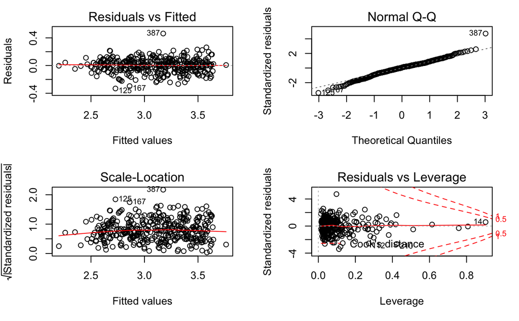

```r
plot(fit4)
```

The residual graph has slightly less heteroscedasticity. Our model also has a better R-squared value. However, I am afraid with so many generated features, this model might overfit.

The previous model (fit4), has many features and as expected, diluted the p-value. There were many collinear features. I want to use the least amount of predictors as possible so after fooling around with the data, I noticed persistent correlation in many of my models, especially displacement:weight and cylinders:horsepower:acceleration.

```r
fit5=lm(log(mpg) ~. + displacement:weight + cylinders:horsepower:acceleration - name, data = Auto)
par(mfrow=c(2,2))
summary(fit5)
```

```
Call:
lm(formula = log(mpg) ~ . + displacement:weight + cylinders:horsepower:acceleration -
    name, data = Auto)

Residuals:
     Min       1Q   Median       3Q      Max
-0.39749 -0.07006  0.00268  0.06024  0.40179

Coefficients:
                                    Estimate Std. Error t value Pr(>|t|)
(Intercept)                        1.563e+00  2.075e-01   7.535 3.57e-13 ***
cylinders                          4.490e-02  1.914e-02   2.346 0.019493 *
displacement                      -2.250e-03  4.557e-04  -4.938 1.18e-06 ***
horsepower                         3.916e-04  7.684e-04   0.510 0.610580
weight                            -3.439e-04  2.709e-05 -12.695  < 2e-16 ***
acceleration                       1.152e-02  4.870e-03   2.366 0.018468 *
year                               3.089e-02  1.715e-03  18.020  < 2e-16 ***
origin                             1.414e-02  9.946e-03   1.422 0.155958
displacement:weight                6.381e-07  8.720e-08   7.317 1.51e-12 ***
cylinders:horsepower:acceleration -2.897e-05  7.846e-06  -3.693 0.000254 ***
---
Signif. codes:  0 ‘***’ 0.001 ‘**’ 0.01 ‘*’ 0.05 ‘.’ 0.1 ‘ ’ 1

Residual standard error: 0.1113 on 382 degrees of freedom
Multiple R-squared:  0.8953,    Adjusted R-squared:  0.8928
F-statistic:   363 on 9 and 382 DF,  p-value: < 2.2e-16
```

Notice that origin and horsepower contributes little to reducing variance. These predictors, if removed will have little impact on R-squared

```r
fit6=lm(log(mpg) ~. + displacement:weight + cylinders:horsepower:acceleration - name - horsepower - origin, data = Auto)
par(mfrow=c(2,2))
summary(fit6)
```

```
Call:
lm(formula = log(mpg) ~ . + displacement:weight + cylinders:horsepower:acceleration -
    name - horsepower - origin, data = Auto)

Residuals:
     Min       1Q   Median       3Q      Max
-0.39221 -0.06873  0.00584  0.06144  0.40258

Coefficients:
                                    Estimate Std. Error t value Pr(>|t|)
(Intercept)                        1.711e+00  1.377e-01  12.422  < 2e-16 ***
cylinders                          3.998e-02  1.396e-02   2.864 0.004419 **
displacement                      -2.440e-03  3.853e-04  -6.331 6.81e-10 ***
weight                            -3.529e-04  2.633e-05 -13.404  < 2e-16 ***
acceleration                       8.842e-03  2.639e-03   3.350 0.000887 ***
year                               3.074e-02  1.686e-03  18.231  < 2e-16 ***
displacement:weight                6.786e-07  8.175e-08   8.301 1.78e-15 ***
cylinders:horsepower:acceleration -2.536e-05  4.744e-06  -5.346 1.54e-07 ***
---
Signif. codes:  0 ‘***’ 0.001 ‘**’ 0.01 ‘*’ 0.05 ‘.’ 0.1 ‘ ’ 1

Residual standard error: 0.1114 on 384 degrees of freedom
Multiple R-squared:  0.8946,    Adjusted R-squared:  0.8926
F-statistic: 465.5 on 7 and 384 DF,  p-value: < 2.2e-16
```

So with the removal of origin and horsepower, we kept relatively the same R-squared and simplified our model. Let’s examine the variance inflation factor for further collinearity in our model

```r
vif(fit6)
```

```
                        cylinders                      displacement
                        17.863050                         51.216542
                           weight                      acceleration
                        15.755739                          1.669884
                             year               displacement:weight
                         1.215453                         57.726733
cylinders:horsepower:acceleration
                        16.865460
```

There is high VIF values for displacement:weight and displacement. Perhaps these two predictors are still too closely related. Let’s try removing displacement to reduce redundant predictors

```r
fit7=lm(log(mpg) ~. + displacement:weight + cylinders:horsepower:acceleration - name - horsepower - origin - displacement, data = Auto)
par(mfrow=c(2,2))
summary(fit7)
```

```
Call:
lm(formula = log(mpg) ~ . + displacement:weight + cylinders:horsepower:acceleration -
    name - horsepower - origin - displacement, data = Auto)

Residuals:
     Min       1Q   Median       3Q      Max
-0.39514 -0.07047  0.00619  0.06658  0.35469

Coefficients:
                                    Estimate Std. Error t value Pr(>|t|)
(Intercept)                        1.641e+00  1.441e-01  11.390  < 2e-16 ***
cylinders                         -1.114e-02  1.195e-02  -0.932 0.351842
weight                            -3.381e-04  2.752e-05 -12.283  < 2e-16 ***
acceleration                       9.638e-03  2.767e-03   3.484 0.000552 ***
year                               3.103e-02  1.769e-03  17.538  < 2e-16 ***
displacement:weight                2.657e-07  5.172e-08   5.137 4.45e-07 ***
cylinders:horsepower:acceleration -1.757e-05  4.809e-06  -3.655 0.000293 ***
---
Signif. codes:  0 ‘***’ 0.001 ‘**’ 0.01 ‘*’ 0.05 ‘.’ 0.1 ‘ ’ 1

Residual standard error: 0.1169 on 385 degrees of freedom
Multiple R-squared:  0.8836,    Adjusted R-squared:  0.8818
F-statistic: 486.9 on 6 and 385 DF,  p-value: < 2.2e-16
```

```r
vif(fit7)
```

```
                        cylinders                            weight
                        11.887610                         15.630759
                     acceleration                              year
                         1.666095                          1.214585
              displacement:weight cylinders:horsepower:acceleration
                        20.979660                         15.731256
```

After removing the displacement predictor, there is a significant decrease in VIF values but also decrease in our R-squared value from 0.8946 to 0.8836. I think this is a significant decrease so I will stick with model fit6.

## Excercise 10

### 10.a

```r
csfit = lm(Sales ~ Price + Urban + US, data=Carseats)
summary(csfit)
```

```
Call:
lm(formula = Sales ~ Price + Urban + US, data = Carseats)

Residuals:
    Min      1Q  Median      3Q     Max
-6.9206 -1.6220 -0.0564  1.5786  7.0581

Coefficients:
             Estimate Std. Error t value Pr(>|t|)
(Intercept) 13.043469   0.651012  20.036  < 2e-16 ***
Price       -0.054459   0.005242 -10.389  < 2e-16 ***
UrbanYes    -0.021916   0.271650  -0.081    0.936
USYes        1.200573   0.259042   4.635 4.86e-06 ***
---
Signif. codes:  0 ‘***’ 0.001 ‘**’ 0.01 ‘*’ 0.05 ‘.’ 0.1 ‘ ’ 1

Residual standard error: 2.472 on 396 degrees of freedom
Multiple R-squared:  0.2393,    Adjusted R-squared:  0.2335
F-statistic: 41.52 on 3 and 396 DF,  p-value: < 2.2e-16
```

Price: Statistically important bc low p-value Urban: not important US: Statistically important when located in US bc low p-value

### 10.c

y_hat = B_0 + B_1 * Price + B_2 * UrbanYes + B_3 * USYes

### 10.d

I can reject the null hypothesis for predictors Price & US

### 10.e

```r
csfit2 = lm(Sales ~ Price + US, data=Carseats)
summary(csfit2)
```

```
Call:
lm(formula = Sales ~ Price + US, data = Carseats)

Residuals:
    Min      1Q  Median      3Q     Max
-6.9269 -1.6286 -0.0574  1.5766  7.0515

Coefficients:
            Estimate Std. Error t value Pr(>|t|)
(Intercept) 13.03079    0.63098  20.652  < 2e-16 ***
Price       -0.05448    0.00523 -10.416  < 2e-16 ***
USYes        1.19964    0.25846   4.641 4.71e-06 ***
---
Signif. codes:  0 ‘***’ 0.001 ‘**’ 0.01 ‘*’ 0.05 ‘.’ 0.1 ‘ ’ 1

Residual standard error: 2.469 on 397 degrees of freedom
Multiple R-squared:  0.2393,    Adjusted R-squared:  0.2354
F-statistic: 62.43 on 2 and 397 DF,  p-value: < 2.2e-16
```

### 10.f

Model in 10.e fits better than the 10.a model because Adujusted R-squared value increased after removing the insignificant Urban predictor.

### 10.g

```r
confint(csfit2)
```

```
                  2.5 %      97.5 %
(Intercept) 11.79032020 14.27126531
Price       -0.06475984 -0.04419543
USYes        0.69151957  1.70776632
```

### 10.h

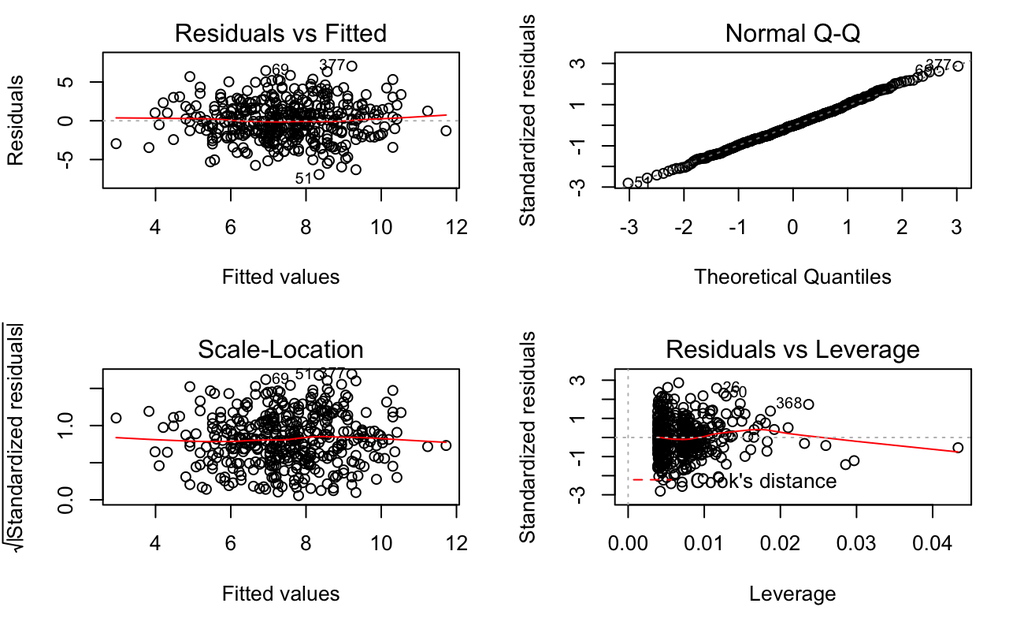

```r
par(mfrow=c(2,2))
plot(csfit2)
```

Yes there are some outliers and one significant high leverage observation.

## 11

```r
set.seed(1)
x=rnorm(100)
y=2*x+rnorm(100)
```

### 11.a

Perform fit without intercep

```r
rfit = lm(y~x+0)
plot(x,y)
abline(rfit)
```

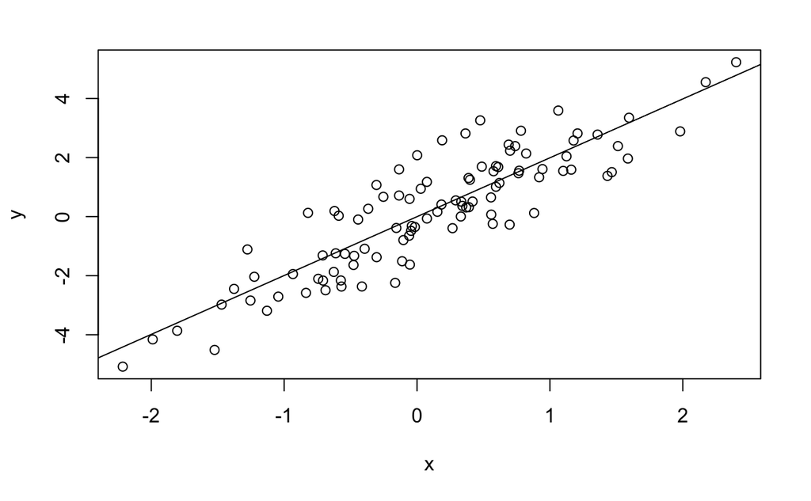

```r
par(mfrow=c(2,2))
```

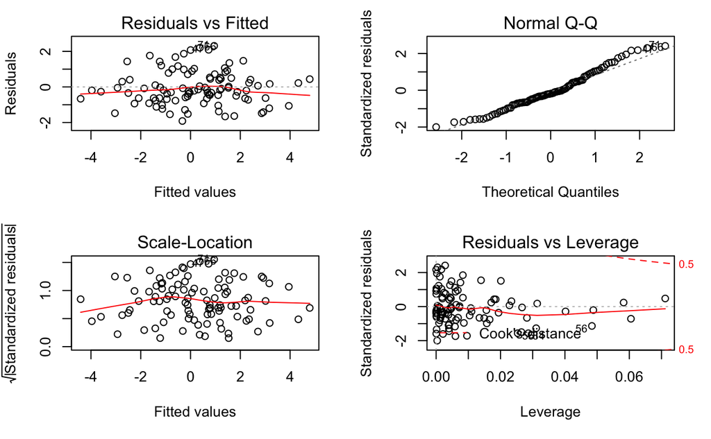

```r
plot(rfit)
```

```r
summary(rfit)
```

```
Call:
lm(formula = y ~ x + 0)

Residuals:
    Min      1Q  Median      3Q     Max
-1.9154 -0.6472 -0.1771  0.5056  2.3109

Coefficients:
  Estimate Std. Error t value Pr(>|t|)
x   1.9939     0.1065   18.73   <2e-16 ***
---
Signif. codes:  0 ‘***’ 0.001 ‘**’ 0.01 ‘*’ 0.05 ‘.’ 0.1 ‘ ’ 1

Residual standard error: 0.9586 on 99 degrees of freedom
Multiple R-squared:  0.7798,    Adjusted R-squared:  0.7776
F-statistic: 350.7 on 1 and 99 DF,  p-value: < 2.2e-16
```

^B = 1.9939 standard error = 0.1065 t-statistics = 18.73 p-value = <2e-16

### 11.b

```r
rfit2 = lm(x~y+0)
plot(y,x)
abline(rfit2)
```

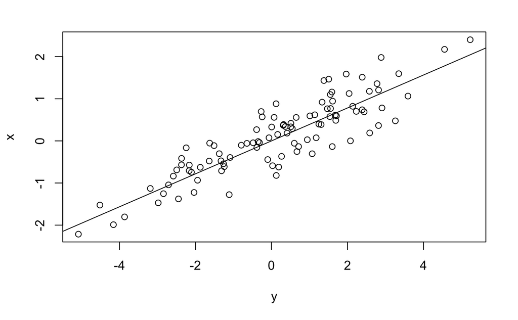

```r
par(mfrow=c(2,2))
```

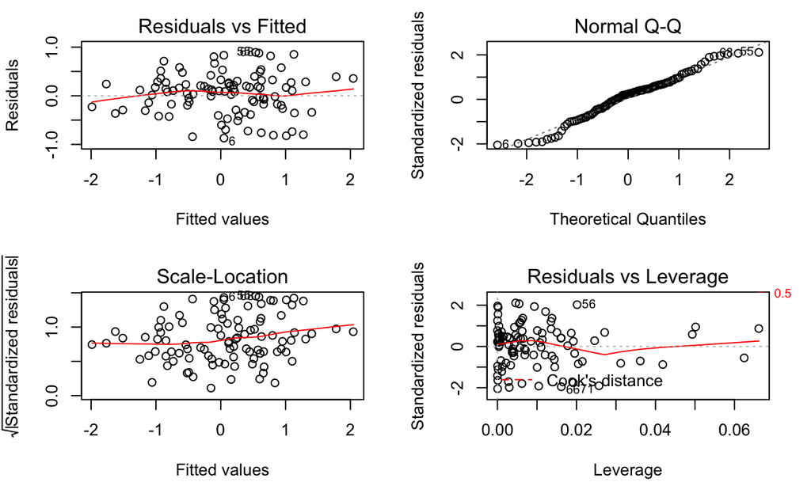

```r
plot(rfit2)
```

```r
summary(rfit2)
```

```
Call:
lm(formula = x ~ y + 0)

Residuals:
    Min      1Q  Median      3Q     Max
-0.8699 -0.2368  0.1030  0.2858  0.8938

Coefficients:
  Estimate Std. Error t value Pr(>|t|)
y  0.39111    0.02089   18.73   <2e-16 ***
---
Signif. codes:  0 ‘***’ 0.001 ‘**’ 0.01 ‘*’ 0.05 ‘.’ 0.1 ‘ ’ 1

Residual standard error: 0.4246 on 99 degrees of freedom
Multiple R-squared:  0.7798,    Adjusted R-squared:  0.7776
F-statistic: 350.7 on 1 and 99 DF,  p-value: < 2.2e-16
```

### 11.c

Mostly everything is the same. Except the ^B value and the standard error related to the cooefficient estimate.

### 11.d

```r
sqrt(length(x) - 1) * sum(x*y) / sqrt(sum(x^2) * sum(y^2) - sum(x*y)^2)
```

```
[1] 18.72593
```

### 11.e

```r
rfit3 = lm(y~x)
rfit4 = lm(x~y)
summary(rfit3)
```

```
Call:
lm(formula = y ~ x)

Residuals:
    Min      1Q  Median      3Q     Max
-1.8768 -0.6138 -0.1395  0.5394  2.3462

Coefficients:
            Estimate Std. Error t value Pr(>|t|)
(Intercept) -0.03769    0.09699  -0.389    0.698
x            1.99894    0.10773  18.556   <2e-16 ***
---
Signif. codes:  0 ‘***’ 0.001 ‘**’ 0.01 ‘*’ 0.05 ‘.’ 0.1 ‘ ’ 1

Residual standard error: 0.9628 on 98 degrees of freedom
Multiple R-squared:  0.7784,    Adjusted R-squared:  0.7762
F-statistic: 344.3 on 1 and 98 DF,  p-value: < 2.2e-16
```

```r
summary(rfit4)
```

```
Call:
lm(formula = x ~ y)

Residuals:
     Min       1Q   Median       3Q      Max
-0.90848 -0.28101  0.06274  0.24570  0.85736

Coefficients:
            Estimate Std. Error t value Pr(>|t|)
(Intercept)  0.03880    0.04266    0.91    0.365
y            0.38942    0.02099   18.56   <2e-16 ***
---
Signif. codes:  0 ‘***’ 0.001 ‘**’ 0.01 ‘*’ 0.05 ‘.’ 0.1 ‘ ’ 1

Residual standard error: 0.4249 on 98 degrees of freedom
Multiple R-squared:  0.7784,    Adjusted R-squared:  0.7762
F-statistic: 344.3 on 1 and 98 DF,  p-value: < 2.2e-16
```

## 12

### 12.a

When sum of y^2 == sum of x^2

### 12.b

```r
x2 = rnorm(100)
y2 = x2*x2 + rnorm(100)
rfit5 = lm(y2 ~ x2)
rfit6 = lm(x2 ~ y2)
summary(rfit5)
```

```
Call:
lm(formula = y2 ~ x2)

Residuals:
    Min      1Q  Median      3Q     Max
-2.8971 -1.1895 -0.2214  0.3849  6.8525

Coefficients:
            Estimate Std. Error t value Pr(>|t|)
(Intercept)  1.11406    0.18608   5.987 3.52e-08 ***
x2          -0.08651    0.18075  -0.479    0.633
---
Signif. codes:  0 ‘***’ 0.001 ‘**’ 0.01 ‘*’ 0.05 ‘.’ 0.1 ‘ ’ 1

Residual standard error: 1.86 on 98 degrees of freedom
Multiple R-squared:  0.002332,  Adjusted R-squared:  -0.007848
F-statistic: 0.2291 on 1 and 98 DF,  p-value: 0.6333
```

```r
summary(rfit6)
```

```
Call:
lm(formula = x2 ~ y2)

Residuals:
    Min      1Q  Median      3Q     Max
-2.7659 -0.5069 -0.0482  0.6837  2.7769

Coefficients:
            Estimate Std. Error t value Pr(>|t|)
(Intercept)  0.05963    0.12124   0.492    0.624
y2          -0.02696    0.05632  -0.479    0.633

Residual standard error: 1.038 on 98 degrees of freedom
Multiple R-squared:  0.002332,  Adjusted R-squared:  -0.007848
F-statistic: 0.2291 on 1 and 98 DF,  p-value: 0.6333
```

^B estimate of lm(y2 ~ x2) = -0.08651 ^B estimate of lm(x2 ~ y2) = -0.02696

### 12.c

```r
set.seed(1)
x3 = rnorm(100)
y3 = x3 + rnorm(100)
# Add difference to x3
x3 = c(x3, sqrt(sum(y3^2) - sum(x3^2)))
y3 = c(y3, 0)
sum(y3^2)
```

```
[1] 171.041
```

```r
sum(x3^2)
```

```
[1] 171.041
```

```r
rfit7 = lm(y3 ~ x3 + 0)
rfit8 = lm(x3 ~ y3 + 0)
summary(rfit7)
```

```
Call:
lm(formula = y3 ~ x3 + 0)

Residuals:
    Min      1Q  Median      3Q     Max
-4.4679 -0.7848 -0.1179  0.8352  2.5595

Coefficients:
   Estimate Std. Error t value Pr(>|t|)
x3  0.47099    0.08821   5.339 5.86e-07 ***
---
Signif. codes:  0 ‘***’ 0.001 ‘**’ 0.01 ‘*’ 0.05 ‘.’ 0.1 ‘ ’ 1

Residual standard error: 1.154 on 100 degrees of freedom
Multiple R-squared:  0.2218,    Adjusted R-squared:  0.2141
F-statistic: 28.51 on 1 and 100 DF,  p-value: 5.857e-07
```

```r
summary(rfit8)
```

```
Call:
lm(formula = x3 ~ y3 + 0)

Residuals:
    Min      1Q  Median      3Q     Max
-1.3541 -0.3654  0.1078  0.5041  9.4861

Coefficients:
   Estimate Std. Error t value Pr(>|t|)
y3  0.47099    0.08821   5.339 5.86e-07 ***
---
Signif. codes:  0 ‘***’ 0.001 ‘**’ 0.01 ‘*’ 0.05 ‘.’ 0.1 ‘ ’ 1

Residual standard error: 1.154 on 100 degrees of freedom
Multiple R-squared:  0.2218,    Adjusted R-squared:  0.2141
F-statistic: 28.51 on 1 and 100 DF,  p-value: 5.857e-07
```

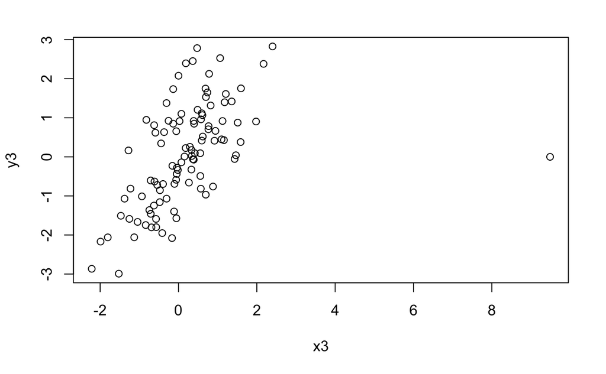

```r
plot(x3, y3)
```

As expected the coefficient estimate is the same. The offlier is the differential point to equalize sum of x^2 to sum of y^2

## 13